# NBA Game Outcome Prediction

Darsh Chaurasia

2024-09-29

# Description

In this project, I will focus on predicting the outcome of NBA games using machine learning models based on key game statistics. I will work with a dataset that includes information such as points scored, field goal percentages, assists, rebounds, and whether the home team won or lost. I will begin by exploring and preprocessing the data, handling any missing values, creating new features like the point difference, and converting categorical variables into dummy variables for modeling. I will perform exploratory data analysis to understand the relationships between various statistics and game outcomes, using visualizations like histograms and heatmaps. I will then train a Random Forest model to predict whether the home team will win, using features like points, assists, and rebounds, and evaluate the model’s performance with metrics such as accuracy and precision. I expect the results to be promising, and I will conclude by discussing how certain statistics, like field goal percentage and point difference, are strong predictors of game outcomes, while also suggesting further improvements for future work.

# Importing Libraries

```r
# Data manipulation and cleaning
library(dplyr)
library(tidyr)
library(readr)

# Data visualization
library(ggplot2)
library(corrplot)
library(ggcorrplot)

# Machine learning and modeling
library(caret)
library(randomForest)

# Performance evaluation
library(pROC)
```

# Importing the data

```r
nba_data <- read_csv("nba.csv")
```

# View the first few rows of the dataset

```r
head(nba_data)
```

```
## # A tibble: 6 × 18
##   game_id game_date  season team_home team_away pts_home fg_pct_home pct_3p_home
##     <dbl> <date>     <chr>  <chr>     <chr>        <dbl>       <dbl>       <dbl>
## 1  1.04e7 2004-10-22 2004-… Golden S… Denver N…       86       0.405       0.3
## 2  1.04e7 2004-10-22 2004-… Charlott… Portland…       69       0.377       0.3
## 3  1.04e7 2004-10-22 2004-… Minnesot… New York…      102       0.523       0.143
## 4  1.04e7 2004-10-22 2004-… Utah Jazz Sacramen…      103       0.507       0.667
## 5  1.04e7 2004-10-22 2004-… Boston C… Brooklyn…       83       0.431       0.273
## 6  1.04e7 2004-10-22 2004-… Los Ange… Los Ange…      113       0.465       0.533
## # ℹ 10 more variables: ft_pct_home <dbl>, ast_home <dbl>, reb_home <dbl>,
## #   pts_away <dbl>, fg_pct_away <dbl>, pct_3p_away <dbl>, ft_pct_away <dbl>,
## #   ast_away <dbl>, reb_away <dbl>, home_team_win <dbl>
```

# Quick Overview of the Data

## Summary of the dataset

```r
summary(nba_data)
```

```
##     game_id           game_date             season           team_home
##  Min.   :10400064   Min.   :2004-10-22   Length:23335       Length:23335
##  1st Qu.:20700616   1st Qu.:2008-11-11   Class :character   Class :character
##  Median :21200539   Median :2013-01-15   Mode  :character   Mode  :character
##  Mean   :21762697   Mean   :2012-12-17
##  3rd Qu.:21700224   3rd Qu.:2017-01-31
##  Max.   :52000211   Max.   :2021-07-20
##   team_away            pts_home      fg_pct_home      pct_3p_home
##  Length:23335       Min.   : 36.0   Min.   :0.2570   Min.   :0.0000
##  Class :character   1st Qu.: 94.0   1st Qu.:0.4220   1st Qu.:0.2860
##  Mode  :character   Median :103.0   Median :0.4600   Median :0.3570
##                     Mean   :103.2   Mean   :0.4611   Mean   :0.3568
##                     3rd Qu.:112.0   3rd Qu.:0.5000   3rd Qu.:0.4290
##                     Max.   :168.0   Max.   :0.6840   Max.   :1.0000
##   ft_pct_home        ast_home        reb_home        pts_away
##  Min.   :0.1430   Min.   : 6.00   Min.   :15.00   Min.   : 33.0
##  1st Qu.:0.6970   1st Qu.:19.00   1st Qu.:39.00   1st Qu.: 91.0
##  Median :0.7650   Median :22.00   Median :43.00   Median :100.0
##  Mean   :0.7598   Mean   :22.68   Mean   :43.28   Mean   :100.4
##  3rd Qu.:0.8290   3rd Qu.:26.00   3rd Qu.:48.00   3rd Qu.:109.0
##  Max.   :1.0000   Max.   :50.00   Max.   :72.00   Max.   :168.0
##   fg_pct_away     pct_3p_away      ft_pct_away        ast_away
##  Min.   :0.244   Min.   :0.0000   Min.   :0.1430   Min.   : 4.00
##  1st Qu.:0.413   1st Qu.:0.2780   1st Qu.:0.6920   1st Qu.:18.00
##  Median :0.449   Median :0.3500   Median :0.7630   Median :21.00
##  Mean   :0.450   Mean   :0.3506   Mean   :0.7578   Mean   :21.35
##  3rd Qu.:0.487   3rd Qu.:0.4210   3rd Qu.:0.8290   3rd Qu.:25.00
##  Max.   :0.674   Max.   :1.0000   Max.   :1.0000   Max.   :46.00
##     reb_away     home_team_win
##  Min.   :19.00   Min.   :0.0000
##  1st Qu.:38.00   1st Qu.:0.0000
##  Median :42.00   Median :1.0000
##  Mean   :42.02   Mean   :0.5896
##  3rd Qu.:46.00   3rd Qu.:1.0000
##  Max.   :81.00   Max.   :1.0000
```

## Visualizing the Distribution of Points Scored by the Home Team

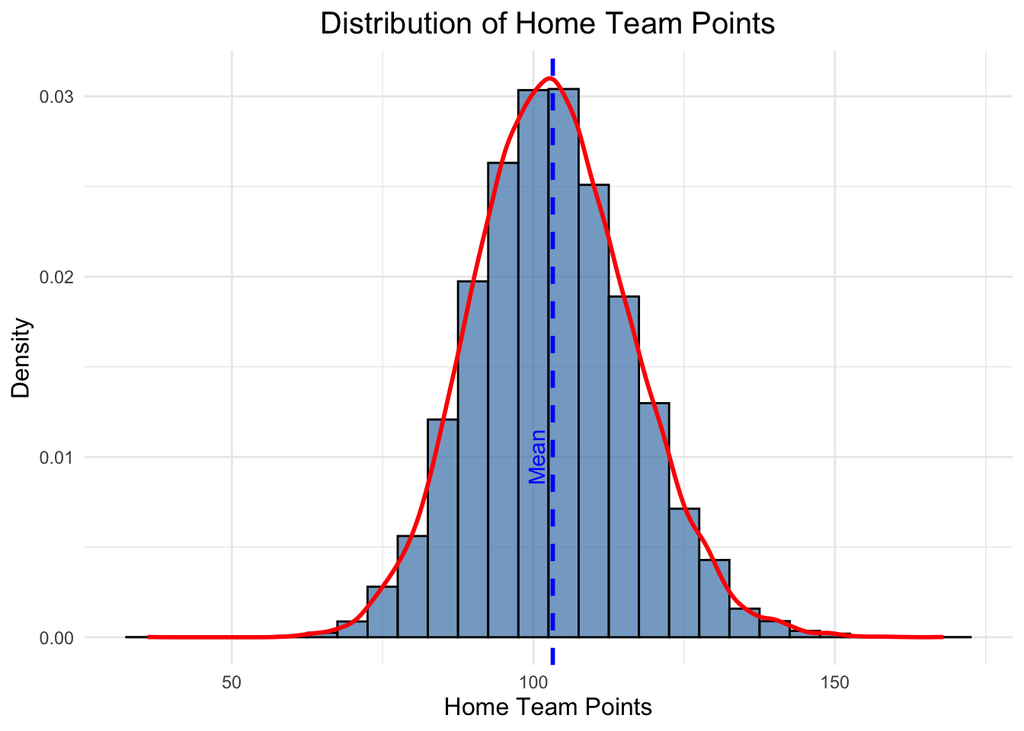

```r
# Histogram of points scored by the home team
ggplot(nba_data, aes(x = pts_home)) +
  geom_histogram(aes(y = after_stat(density)), binwidth = 5, fill = "steelblue",
                 color = "black",alpha = 0.7) +
  geom_density(color = "red", linewidth = 1) +
  labs(title = "Distribution of Home Team Points",
       x = "Home Team Points",
       y = "Density") +
  theme_minimal() +
  theme(plot.title = element_text(hjust = 0.5, size = 15),
        axis.title.x = element_text(size = 12),
        axis.title.y = element_text(size = 12)) +
  geom_vline(aes(xintercept = mean(pts_home)), color = "blue", linetype = "dashed",
             linewidth = 1) +
  annotate("text", x = mean(nba_data$pts_home), y = 0.01, label = "Mean", color = "blue",
           angle = 90, vjust = -0.5)
```

# Pre-Processing the Data

Handling missing values, creating new features, and converting categorical variables.

## Handling Missing Values

```r
# Check for missing values
sum(is.na(nba_data))
```

```
## [1] 0
```

```r
# Impute or remove missing values if necessary
nba_data <- nba_data %>% mutate_if(is.numeric, ~ ifelse(is.na(.),
median(., na.rm = TRUE), .))
```

## Creating New Features

Create a new feature representing the point difference between the home and away teams.

```r
# Create a new feature: Point Difference
nba_data <- nba_data %>%
  mutate(PointDifference = pts_home - pts_away)
```

## Converting Categorical Variables to Dummy Variables

Convert team names and other categorical variables into dummy variables for modeling.

```r
# Convert categorical variables into factors
nba_data$team_home <- as.factor(nba_data$team_home)
nba_data$team_away <- as.factor(nba_data$team_away)

# Use dummy encoding for team names
nba_data_encoded <- model.matrix(~ team_home + team_away + 0, data = nba_data) %>%
  as.data.frame()

# Combine the dummy variables back with the original dataset
# (excluding the original team columns)
nba_data <- cbind(nba_data_encoded, nba_data %>% select(-team_home, -team_away))
```

# Exploratory Data Analysis (EDA)

Exploratory analysis to understand the relationships between different game statistics and the outcome.

## Distribution of Game Outcomes

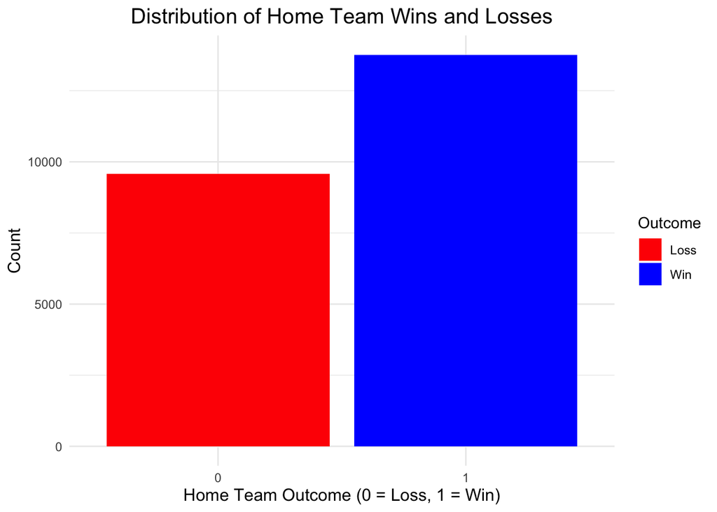

```r
# Visualize the distribution of game outcomes (win/loss)
ggplot(nba_data, aes(x = factor(home_team_win), fill = factor(home_team_win))) +
  geom_bar() +
  scale_fill_manual(values = c("0" = "red", "1" = "blue"),
                    labels = c("0" = "Loss", "1" = "Win")) +
  labs(title = "Distribution of Home Team Wins and Losses",
       x = "Home Team Outcome (0 = Loss, 1 = Win)",
       y = "Count",
       fill = "Outcome") +
  theme_minimal() +
  theme(plot.title = element_text(hjust = 0.5, size = 15),
        axis.title.x = element_text(size = 12),
        axis.title.y = element_text(size = 12),
        legend.position = "right")
```

## Correlation Analysis

- r represents the correlation coefficient
- x and y represent two variables
- n is the number of data points
- sum of products of differences from mean
  $$r = \frac{ \sum_{i=1}^{n} (x_i - \bar{x})(y_i - \bar{y}) }
  { \sqrt{ \sum_{i=1}^{n} (x_i - \bar{x})^2 } \cdot \sqrt{
  \sum_{i=1}^{n} (y_i - \bar{y})^2 } }$$

```r
# Correlation calculation in R
# Select numerical columns from the dataset
nba_num_data <- nba_data %>% select(pts_home, pts_away, PointDifference,
                                    ast_home, reb_home, ast_away, reb_away)

# Calculate correlation matrix
cor_matrix <- cor(nba_num_data)

# View the correlation matrix
cor_matrix
```

```
##                   pts_home   pts_away PointDifference    ast_home    reb_home
## pts_home         1.0000000  0.4711389       0.5081308  0.59857143  0.16266086
## pts_away         0.4711389  1.0000000      -0.5202995  0.18057243 -0.15585565
## PointDifference  0.5081308 -0.5202995       1.0000000  0.40320083  0.30966759
## ast_home         0.5985714  0.1805724       0.4032008  1.00000000  0.06274468
## reb_home         0.1626609 -0.1558557       0.3096676  0.06274468  1.00000000
## ast_away         0.1975738  0.5855734      -0.3804936  0.14157166 -0.10331531
## reb_away        -0.1451255  0.1747682      -0.3111575 -0.10913399  0.06806770
##                    ast_away    reb_away
## pts_home         0.19757379 -0.14512553
## pts_away         0.58557344  0.17476825
## PointDifference -0.38049362 -0.31115746
## ast_home         0.14157166 -0.10913399
## reb_home        -0.10331531  0.06806770
## ast_away         1.00000000  0.07099368
## reb_away         0.07099368  1.00000000
```

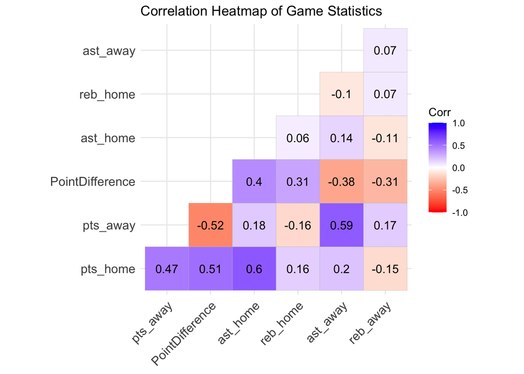

```r
# install.packages("ggcorrplot")
library(ggcorrplot)

# Select numerical columns for correlation analysis
nba_num_data <- nba_data %>% select(pts_home, pts_away, PointDifference, ast_home,
                                    reb_home, ast_away, reb_away)

# Compute the correlation matrix
cor_matrix <- cor(nba_num_data)

# Create an advanced correlation heatmap with ggcorrplot
ggcorrplot(cor_matrix,
           method = "square",         # Use squares to represent the correlation
           type = "lower",            # Display only the lower triangle of the matrix
           lab = TRUE,                # Show correlation coefficients
           lab_size = 4,
           colors = c("red", "white", "blue"),  # Color gradient
           title = "Correlation Heatmap of Game Statistics",
           ggtheme = theme_minimal())
```